# RetentionAnalytics: User Retention & Funnel Analytics

Author

Ludovic Njiosseu, MS Biostatistics

Published

May 19, 2026

## Overview

This project replicates large-scale consumer product analytics: conversion funnel analysis, cohort retention modeling, DAU/MAU tracking, predictive power-user identification, and A/B experimentation design — all in R on a simulated dataset of 5,000 users.

## Module 1 — Data Simulation

```r
source("scripts/01_simulate_data.R")
```

```
Users: 5000 | Sessions: 34542
Conversion rate: 12.62%
Power users: 20.0%
Saved: data/users.csv, data/sessions.csv
```

Users are generated across 12 monthly signup cohorts with acquisition channel, device type, plan type, and age group. Funnel completion is stochastic with plan-type-conditional pass-through rates. Monthly retention follows a decaying curve with a behavioral power-user boost.

## Module 2 — Conversion Funnel

```r
source("scripts/02_funnel_analysis.R")
```

```
--- Overall Funnel ---
# A tibble: 5 × 6
  step       col                    n pct_of_signup step_conversion drop_off_pct
  <chr>      <chr>              <dbl>         <dbl>           <dbl>        <dbl>
1 Signup     completed_signup    5000         100              NA           NA
2 Onboarding completed_onboard…  3836          76.7            76.7         23.3
3 Activation completed_activat…  2402          48              62.6         37.4
4 Engagement completed_engagem…  1365          27.3            56.8         43.2
5 Conversion completed_convers…   631          12.6            46.2         53.8

--- Funnel by Plan Type ---
# A tibble: 3 × 6
  plan_type n_users pct_onboarding pct_activation pct_engagement pct_conversion
  <chr>       <int>          <dbl>          <dbl>          <dbl>          <dbl>
1 free         3025           71.2           38.7           18.7            2.3
2 paid          718           91.8           78             59.1           59.1
3 trial        1257           81.4           53.4           29.9           10.9

--- Conversion by Acquisition Channel ---
# A tibble: 5 × 4
  acquisition_channel n_users pct_activation pct_conversion
  <chr>                 <int>          <dbl>          <dbl>
1 referral                732           46.6           14.9
2 paid_search            1203           48.5           12.5
3 email                   490           49.4           12.4
4 social                 1036           48             12.3
5 organic                1539           48             12

--- Top Drop-off Points ---
# A tibble: 4 × 5
  step           n pct_of_signup step_conversion drop_off_pct
  <chr>      <dbl>         <dbl>           <dbl>        <dbl>
1 Conversion   631          12.6            46.2         53.8
2 Engagement  1365          27.3            56.8         43.2
3 Activation  2402          48              62.6         37.4
4 Onboarding  3836          76.7            76.7         23.3

Projected conversion lift from +5pp activation fix: 10.4%

Funnel analysis complete.
```

```r
library(tidyverse)
```

### Funnel Visualization

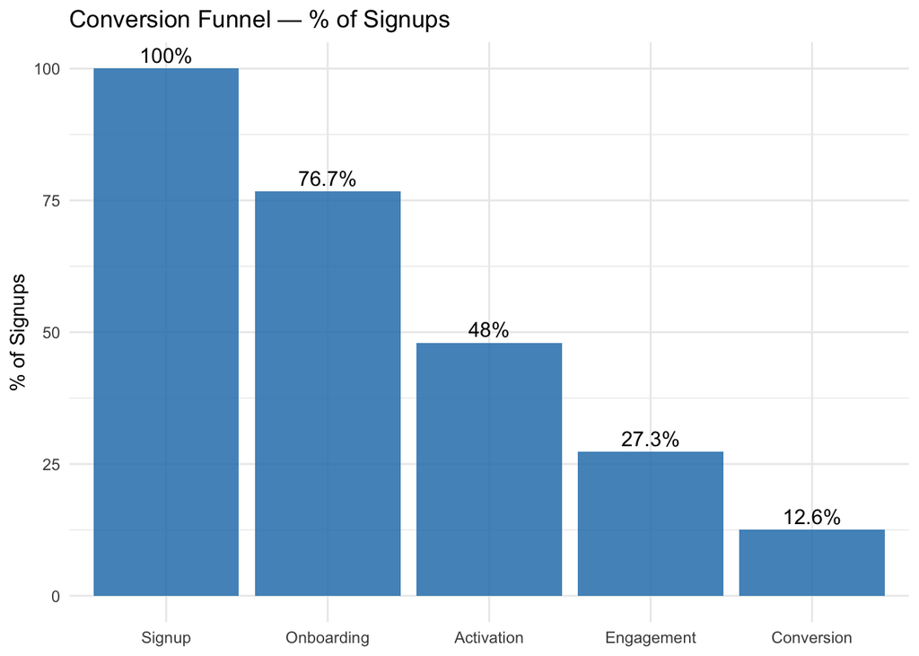

```r
funnel <- read_csv("outputs/funnel_overall.csv", show_col_types = FALSE)
funnel %>%
  mutate(step = fct_inorder(step)) %>%
  ggplot(aes(x = step, y = pct_of_signup)) +
  geom_col(fill = "#2980b9", alpha = 0.85) +
  geom_text(aes(label = paste0(pct_of_signup, "%")), vjust = -0.4, size = 4) +
  labs(title = "Conversion Funnel — % of Signups",
       x = NULL, y = "% of Signups") +
  theme_minimal()
```

### Top Drop-off Points

```r
dropoffs <- read_csv("outputs/funnel_dropoffs.csv", show_col_types = FALSE)
knitr::kable(dropoffs, caption = "Funnel Drop-off by Step")
```

Funnel Drop-off by Step

| step | n | pct_of_signup | step_conversion | drop_off_pct |
| --- | --- | --- | --- | --- |
| Conversion | 631 | 12.6 | 46.2 | 53.8 |
| Engagement | 1365 | 27.3 | 56.8 | 43.2 |
| Activation | 2402 | 48.0 | 62.6 | 37.4 |
| Onboarding | 3836 | 76.7 | 76.7 | 23.3 |

The three critical drop-off points are identified by step-over-step conversion loss. A +5pp intervention at the activation step is projected to produce measurable downstream conversion lift (see `outputs/funnel_improvement_projection.csv`).

### Conversion by Acquisition Channel

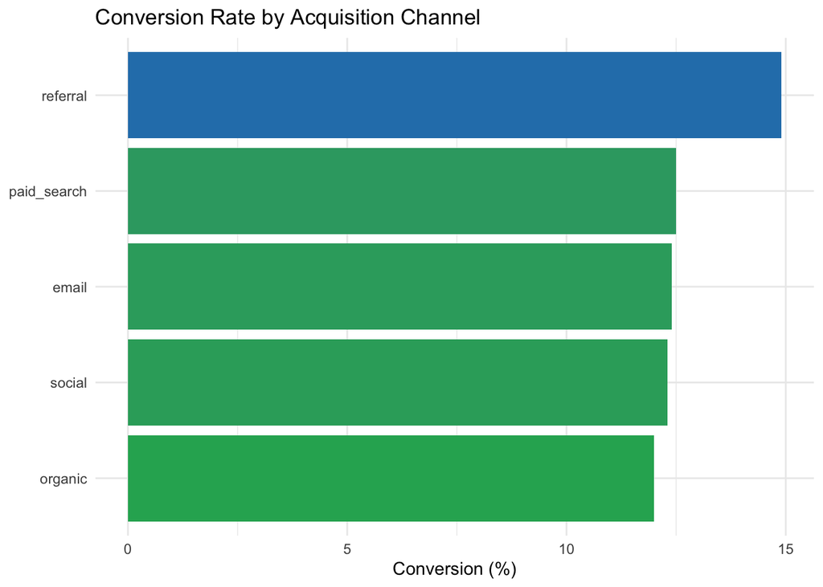

```r
funnel_ch <- read_csv("outputs/funnel_by_channel.csv", show_col_types = FALSE)
funnel_ch %>%
  mutate(acquisition_channel = fct_reorder(acquisition_channel, pct_conversion)) %>%
  ggplot(aes(x = acquisition_channel, y = pct_conversion, fill = pct_conversion)) +
  geom_col() + coord_flip() +
  scale_fill_gradient(low = "#27ae60", high = "#2980b9") +
  labs(title = "Conversion Rate by Acquisition Channel",
       x = NULL, y = "Conversion (%)") +
  theme_minimal() + theme(legend.position = "none")
```

## Module 3 — Retention Cohorts & DAU/MAU

```r
source("scripts/03_retention_cohorts.R")
```

```
--- Overall Retention Curve ---
# A tibble: 12 × 3
   months_since_signup retention_rate n_active
                 <int>          <dbl>    <dbl>
 1                   1           74.2     3710
 2                   2           58.9     2943
 3                   3           48.7     2437
 4                   4           40.9     2045
 5                   5           35.1     1756
 6                   6           32.0     1598
 7                   7           28.1     1404
 8                   8           26.1     1306
 9                   9           23.9     1195
10                  10           22.9     1147
11                  11           21.9     1094
12                  12           21.2     1060

--- Month-6 Retention by Cohort ---
# A tibble: 12 × 3
   cohort_month m6_retention_rate n_users
   <date>                   <dbl>   <int>
 1 2023-01-01                34.5     342
 2 2023-02-01                29.3     328
 3 2023-03-01                32.8     363
 4 2023-04-01                30.0     446
 5 2023-05-01                32.8     481
 6 2023-06-01                29.8     546
 7 2023-07-01                33.3     468
 8 2023-08-01                28.9     533
 9 2023-09-01                35.1     459
10 2023-10-01                35.6     416
11 2023-11-01                29.3     369
12 2023-12-01                33.3     249

--- Monthly DAU/MAU Summary ---
# A tibble: 3 × 4
  year_month avg_dau   mau avg_stickiness
  <chr>        <dbl> <int>          <dbl>
1 2024-01        381  1363           27.9
2 2024-02        378  1359           27.8
3 2024-03        380  1362           27.9

--- Engagement Trend ---
# A tibble: 3 × 4
  year_month total_sessions avg_session_length avg_actions
  <chr>               <int>              <dbl>       <dbl>
1 2024-01             11797               8.05        3.95
2 2024-02             10969               8.02        4.04
3 2024-03             11776               8.01        4.02

Retention cohort analysis complete.
```

### Retention Curves by Plan Type

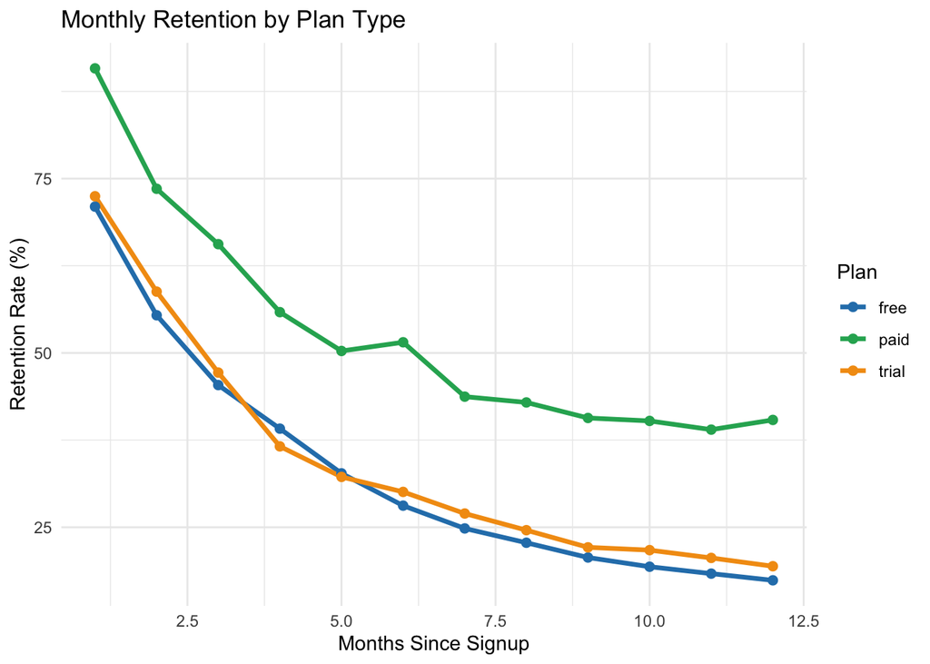

```r
ret_plan <- read_csv("outputs/retention_by_plan.csv", show_col_types = FALSE)
ggplot(ret_plan, aes(x = months_since_signup, y = retention_rate,
                     color = plan_type, group = plan_type)) +
  geom_line(size = 1.2) + geom_point(size = 2) +
  scale_color_manual(values = c(free = "#2980b9", trial = "#f39c12", paid = "#27ae60")) +
  labs(title = "Monthly Retention by Plan Type",
       x = "Months Since Signup", y = "Retention Rate (%)", color = "Plan") +
  theme_minimal()
```

### Power User vs Regular Retention

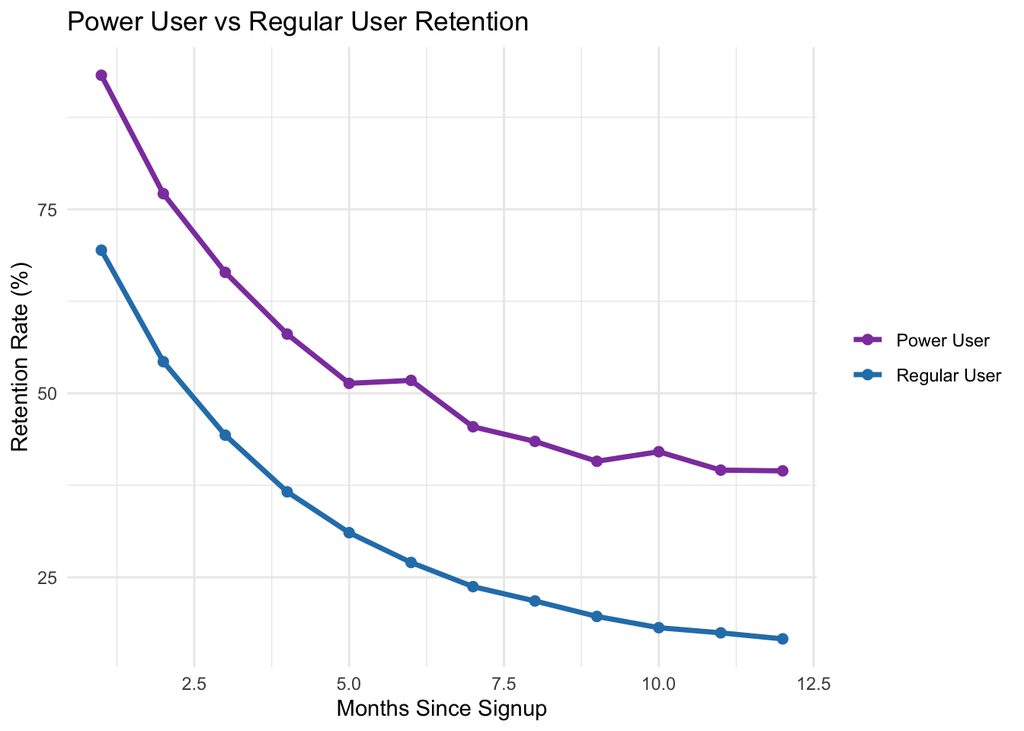

```r
ret_power <- read_csv("outputs/retention_by_power.csv", show_col_types = FALSE)
ggplot(ret_power, aes(x = months_since_signup, y = retention_rate,
                       color = segment, group = segment)) +
  geom_line(size = 1.2) + geom_point(size = 2) +
  scale_color_manual(values = c("Power User" = "#8e44ad", "Regular User" = "#2980b9")) +
  labs(title = "Power User vs Regular User Retention",
       x = "Months Since Signup", y = "Retention Rate (%)", color = NULL) +
  theme_minimal()
```

### Month-6 Retention by Signup Cohort

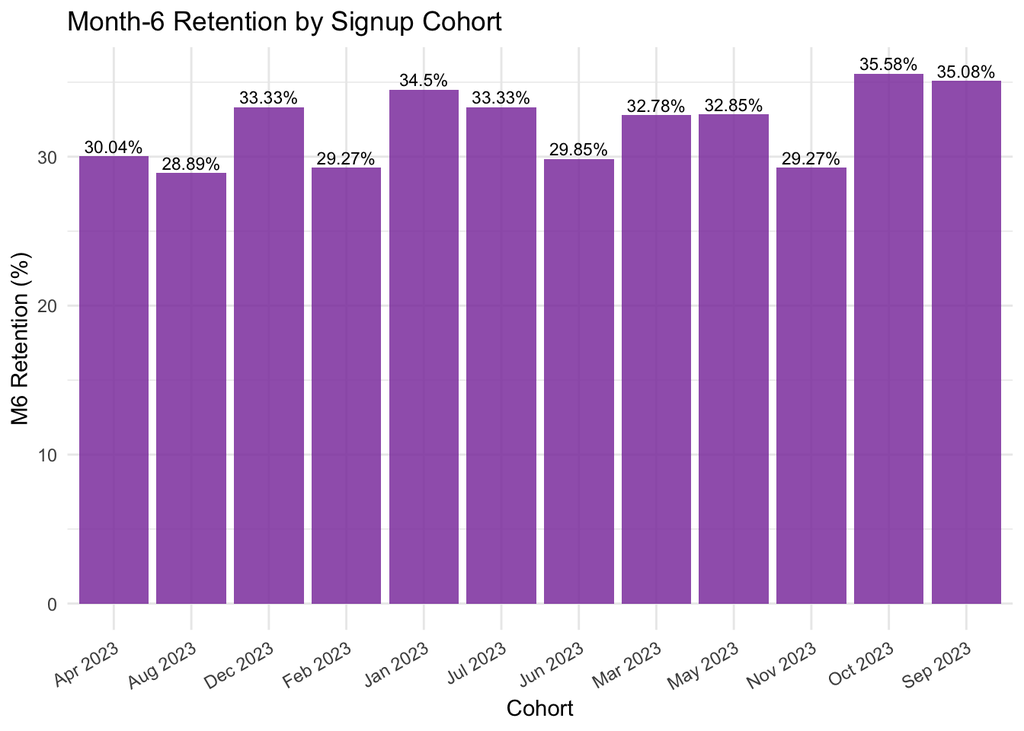

```r
m6 <- read_csv("outputs/m6_retention_by_cohort.csv", show_col_types = FALSE)
m6 %>%
  mutate(cohort_month = format(as.Date(cohort_month), "%b %Y")) %>%
  ggplot(aes(x = cohort_month, y = m6_retention_rate)) +
  geom_col(fill = "#8e44ad", alpha = 0.85) +
  geom_text(aes(label = paste0(m6_retention_rate, "%")), vjust = -0.3, size = 3) +
  labs(title = "Month-6 Retention by Signup Cohort",
       x = "Cohort", y = "M6 Retention (%)") +
  theme_minimal() +
  theme(axis.text.x = element_text(angle = 30, hjust = 1))
```

### DAU / MAU Stickiness

```r
dau_mau <- read_csv("outputs/dau_mau_summary.csv", show_col_types = FALSE)
knitr::kable(dau_mau, caption = "DAU/MAU Stickiness by Month")
```

DAU/MAU Stickiness by Month

| year_month | avg_dau | mau | avg_stickiness |
| --- | --- | --- | --- |
| 2024-01 | 381 | 1363 | 27.92 |
| 2024-02 | 378 | 1359 | 27.83 |
| 2024-03 | 380 | 1362 | 27.89 |

## Module 4 — Predictive Model & Experimentation

```r
source("scripts/04_predictive_model.R")
```

```
Month-6 Retention Prediction AUC-ROC: 0.5946
Optimal threshold: 0.3734 | Sensitivity: 0.3464 | Specificity: 0.8470

--- Power User Signature: Feature Importance ---
# A tibble: 8 × 3
  feature              coefficient odds_ratio
  <chr>                      <dbl>      <dbl>
1 is_paid                   0.666       1.95
2 power_user_score          0.433       1.54
3 completed_engagement      0.271       1.31
4 completed_activation      0.178       1.19
5 completed_onboarding     -0.0967      0.908
6 is_referral              -0.0523      0.949
7 is_desktop               -0.0504      0.951
8 is_trial                  0.0093      1.01

--- A/B Testing Framework ---
Power analysis: detect 5pp lift | alpha=0.05 | power=0.80 | n per arm = 1251
Observed lift: 6.08pp | p-value: 0.0004 | Significant: YES

--- Novelty Effect Check ---
# A tibble: 2 × 2
  period                 lift_obs
  <chr>                     <dbl>
1 Weeks 1-2 (novelty)      0.071
2 Weeks 3-4 (stabilized)   0.0513

Predictive modeling and A/B framework complete.
```

### Power User Behavioral Signature

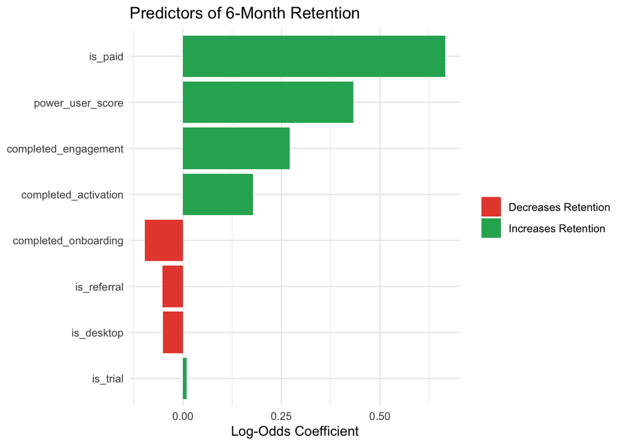

```r
feat_imp <- read_csv("outputs/power_user_feature_importance.csv", show_col_types = FALSE)
feat_imp %>%
  mutate(feature = fct_reorder(feature, abs(coefficient)),
         direction = ifelse(coefficient > 0, "Increases Retention", "Decreases Retention")) %>%
  ggplot(aes(x = feature, y = coefficient, fill = direction)) +
  geom_col() + coord_flip() +
  scale_fill_manual(values = c("Increases Retention" = "#27ae60",
                               "Decreases Retention" = "#e74c3c")) +
  labs(title = "Predictors of 6-Month Retention",
       x = NULL, y = "Log-Odds Coefficient", fill = NULL) +
  theme_minimal()
```

```r
ret_metrics <- read_csv("outputs/retention_model_metrics.csv", show_col_types = FALSE)
knitr::kable(ret_metrics, caption = "Retention Prediction Model Metrics")
```

Retention Prediction Model Metrics

| metric | value |
| --- | --- |
| AUC-ROC | 0.5946 |
| Optimal Threshold | 0.3734 |
| Sensitivity | 0.3464 |
| Specificity | 0.8470 |

### A/B Experiment Results

```r
ab_summary <- read_csv("outputs/ab_experiment_summary.csv", show_col_types = FALSE)
knitr::kable(ab_summary, caption = "Onboarding A/B Experiment Summary")
```

Onboarding A/B Experiment Summary

| metric | value |
| --- | --- |
| Control retention | 69.62 |
| Treatment retention | 75.7 |
| Observed lift | 6.08pp |
| p-value | 4e-04 |
| n per arm | 1251 |
| Significant | YES |

The experimentation framework includes: hypothesis framing, power analysis (two-proportion z-test), metric selection (M1 retention as primary, conversion rate as guardrail), and novelty-effect correction by comparing early vs. stabilized weeks.

## Reproducibility

```r
install.packages(c("tidyverse", "pROC", "shiny", "bslib", "bsicons"))

source("scripts/01_simulate_data.R")
source("scripts/02_funnel_analysis.R")
source("scripts/03_retention_cohorts.R")
source("scripts/04_predictive_model.R")

shiny::runApp("shiny/")
quarto::quarto_render("retentionanalytics_report.qmd")
```

## Limitations & Extensions

- Session data covers 3 months; production would use full lifecycle data.
- The power user model is trained on first-month features; real systems use streaming behavioral signals updated daily.
- No network/referral graph effects are modeled — relevant for virality-driven products.
- Revenue metrics (LTV, ARPU) are not included but are the natural next layer.